# Predict rental prices in Berlin with simple and multiple linear regression

Vinh Hung le vinhhle.github.io  
01/23/2020

Berlin is the capital and also the most populous city in Germany with more than 3.6 millions inhabitants (2019). People from all walks of life live, work, and study in this major metropolitan. Despite a developed real estate market, it is not simple to find an apartment that suits your budget and lifestyle.

In this project, we’ll work with a [real estate dataset](https://www.kaggle.com/datasets/corrieaar/apartment-rental-offers-in-germany) scraped by [Corrie Bartelheimer](https://github.com/corriebar) from Immoscout24, the biggest real estate in Germany. It includes information about rental properties in all 16 states of Germany.

```r
library(tidyverse)
library(cowplot)
library(reshape2)
library(colorspace)
library(ggridges)
font = "Avenir Next"
text_color = "#353D42"

# import data
germany_real_estate <- read.csv("/Users/huvi611/Downloads/immo_data.csv")
```

Some questions:

1. What is the relationship between the base rent and other features, such as service, area, year of construction, and the availability of balcony, garden, kitchen, parking, etc?
2. Which feature has the most effect on the base rent?
3. Is there an interaction effect between features?
4. Can we predict future base rents based on the provided information?

# Cleaning the Dataset

Let’s start with cleaning up the mess. We first need to choose interested features and remove some unnecessary variables, NA values, and duplicate observations.

```r
berlin_real_estate <- germany_real_estate %>%
  filter(regio1 == "Berlin") %>%
  select(baserent = baseRent, service = serviceCharge, area = livingSpace, room = noRooms, year = yearConstructed,  parking = noParkSpaces, balcony, kitchen = hasKitchen, cellar, garden, interior = interiorQual, new = newlyConst, lift) %>%
  drop_na() %>%
  distinct()

rmarkdown::paged_table(berlin_real_estate, options = list(cols.print = 5))
```

| baserent | service | area | room | year | parking | balcony | kitchen | cellar | garden | interior | new | lift |
| --- | --- | --- | --- | --- | --- | --- | --- | --- | --- | --- | --- | --- |
| 1150.00 | 150.00 | 46.40 | 2.0 | 2019 | 1 | TRUE | TRUE | TRUE | FALSE | luxury | TRUE | TRUE |
| 1048.00 | 232.00 | 83.14 | 3.0 | 2014 | 1 | TRUE | TRUE | TRUE | FALSE | sophisticated | FALSE | FALSE |
| 875.00 | 250.00 | 81.00 | 2.0 | 1990 | 1 | TRUE | TRUE | TRUE | TRUE | sophisticated | FALSE | FALSE |
| 749.00 | 170.00 | 69.75 | 2.0 | 1990 | 1 | TRUE | TRUE | FALSE | FALSE | normal | FALSE | TRUE |
| 1720.00 | 700.00 | 220.00 | 4.0 | 1998 | 2 | TRUE | TRUE | TRUE | TRUE | sophisticated | FALSE | FALSE |
| 890.00 | 300.00 | 83.00 | 3.0 | 2016 | 1 | TRUE | TRUE | TRUE | TRUE | sophisticated | FALSE | TRUE |
| 1763.63 | 368.76 | 160.33 | 7.0 | 2019 | 1 | TRUE | FALSE | TRUE | FALSE | sophisticated | TRUE | TRUE |
| 510.00 | 110.00 | 38.00 | 1.0 | 2016 | 50 | TRUE | FALSE | FALSE | FALSE | sophisticated | FALSE | TRUE |
| 745.00 | 75.00 | 68.00 | 2.5 | 1997 | 1 | FALSE | TRUE | TRUE | TRUE | normal | FALSE | FALSE |
| 2215.00 | 485.00 | 119.00 | 4.0 | 2019 | 1 | TRUE | TRUE | TRUE | FALSE | sophisticated | TRUE | TRUE |

[output cut: 1270 more lines]

The dataset contains the following features about rental properties in Berlin:  
- baserent: base renting price (in euro)  
- service: extra costs, such as internet or electricity (in euro)  
- area: living space (in sqm) - room: number of rooms - year: construction year  
- parking: number of parking spaces  
- balcony: does the property has balcony?  
- kitchen: does the property has kitchen?  
- cellar: does the property has cellar?  
- garden: is there a garden?  
- interior: interior quality  
- new: a new property or not?  
- lift: is there a lift or not?

Now we need to check whether outliers exist in the dataset. There are generally two types of outliers:  
- Outliers result from a mistake or error  
- Outliers represent real observations, but look very different to others

The simplest way to detect an outlier is to make a scatterplot. First, take a look at the following plot between `baserent` and `service`

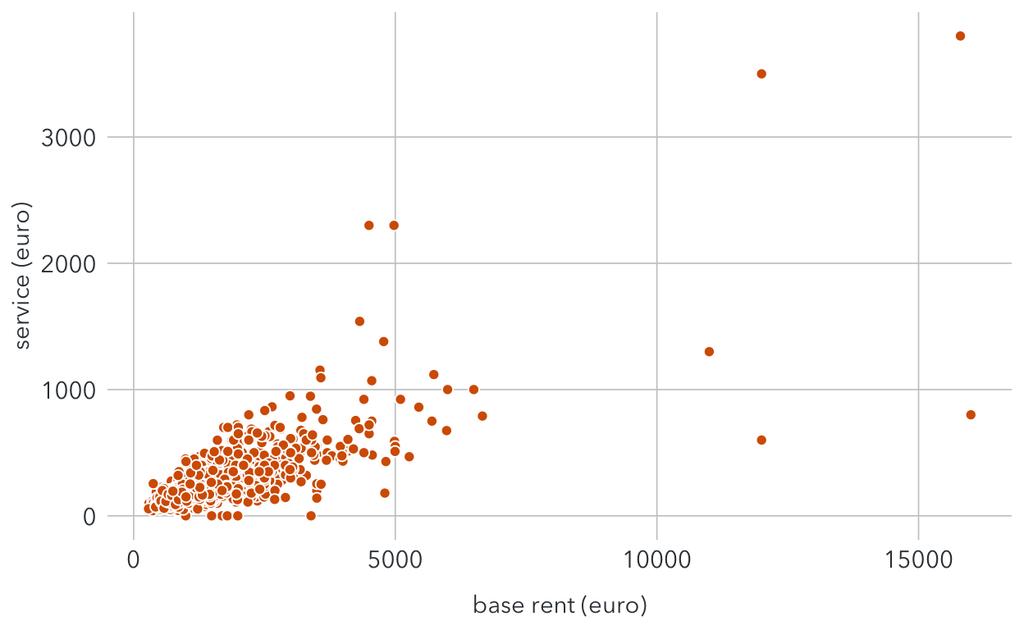

```r
ggplot (berlin_real_estate, aes(x = baserent, y = service)) +
  geom_point(shape = 21, fill = "#D55E00", color = "white", size = 2) +
  scale_x_continuous(name = "base rent (euro)") +
  scale_y_continuous(name = "service (euro)") +
  theme(
    axis.ticks = element_blank(),
    axis.text = element_text(family = font, size = 11, color = text_color),
    axis.title = element_text(family = font, size = 11, color = text_color),
    panel.background = element_rect(fill = "white"),
    panel.grid.major = element_line(color = "#cbcbcb", size = 0.3),
    axis.title.x = element_text(margin = margin (t = 10)),
    legend.position = "none")
```

Here’s what we have after removing outliers.

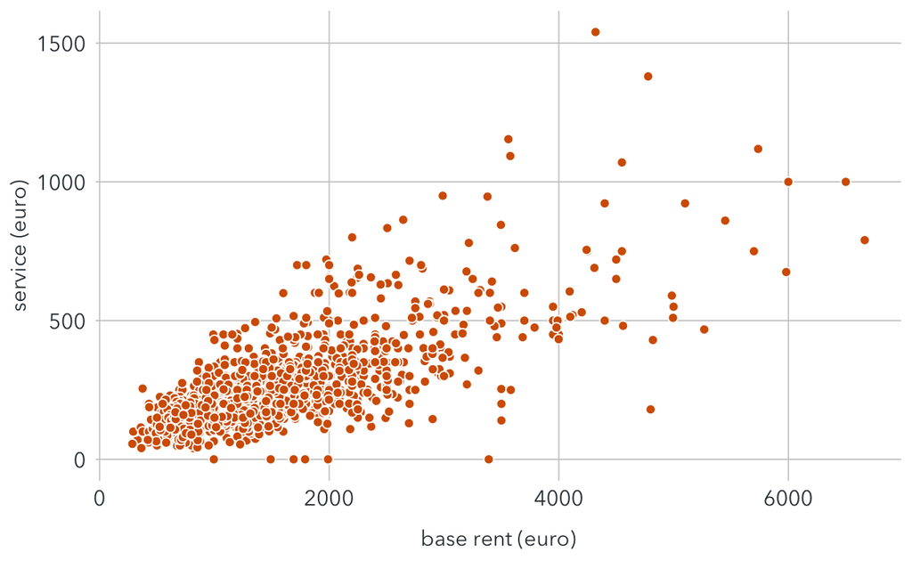

```r
ggplot(filter(berlin_real_estate, baserent < 10000 & service < 2000), aes(x = baserent, y = service)) +
  geom_point(shape = 21, fill = "#D55E00", color = "white", size = 2) +
  scale_x_continuous(name = "base rent (euro)") +
  scale_y_continuous(name = "service (euro)") +
  theme(
    axis.ticks = element_blank(),
    axis.text = element_text(family = font, size = 11, color = text_color),
    axis.title = element_text(family = font, size = 11, color = text_color),
    panel.background = element_rect(fill = "white"),
    panel.grid.major = element_line(color = "#cbcbcb", size = 0.3),
    axis.title.x = element_text(margin = margin (t = 10)),
    legend.position = "none")
```

Now it is easier to notice that there seems to be a linear relationship between the base rent and service.

With the same procedure, we may filter observations with `room` < 25. Below graphs show before and after removing `room` outliers.

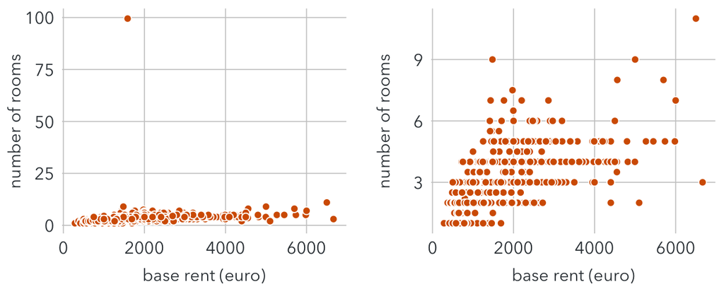

```r
p1 <- ggplot(filter(berlin_real_estate, baserent < 10000), aes(x = baserent, y = room)) +
  geom_point(shape = 21, fill = "#D55E00", color = "white", size = 2) +
  scale_x_continuous(name = "base rent (euro)") +
  scale_y_continuous(name = "number of rooms") +
  theme(
    axis.ticks = element_blank(),
    axis.text = element_text(family = font, size = 11, color = text_color),
    axis.title = element_text(family = font, size = 11, color = text_color),
    panel.background = element_rect(fill = "white"),
    panel.grid.major = element_line(color = "#cbcbcb", size = 0.3),
    axis.title.x = element_text(margin = margin (t = 10)),
    legend.position = "none")
p2 <- ggplot(filter(berlin_real_estate, baserent < 10000 & room < 25), aes(x = baserent, y = room)) +
  geom_point(shape = 21, fill = "#D55E00", color = "white", size = 2) +
  scale_x_continuous(name = "base rent (euro)") +
  scale_y_continuous(name = "number of rooms") +
  theme(
    axis.ticks = element_blank(),
    axis.text = element_text(family = font, size = 11, color = text_color),
    axis.title = element_text(family = font, size = 11, color = text_color),
    panel.background = element_rect(fill = "white"),
    panel.grid.major = element_line(color = "#cbcbcb", size = 0.3),
    axis.title.x = element_text(margin = margin (t = 10)),
    legend.position = "none")
plot_grid(
  p1, NULL, p2,
  nrow = 1, align = 'hv', rel_widths = c(1, .04, 1, .04, 1))
```

```r
berlin_adjusted <- berlin_real_estate %>%
  filter(baserent < 10000,
         service < 1500,
         room < 25,
         !interior %in% c("simple"))
```

# Exploratory Data Analysis

Now let’s find out some interesting facts about the dataset. Start with the distribution of the base rent.

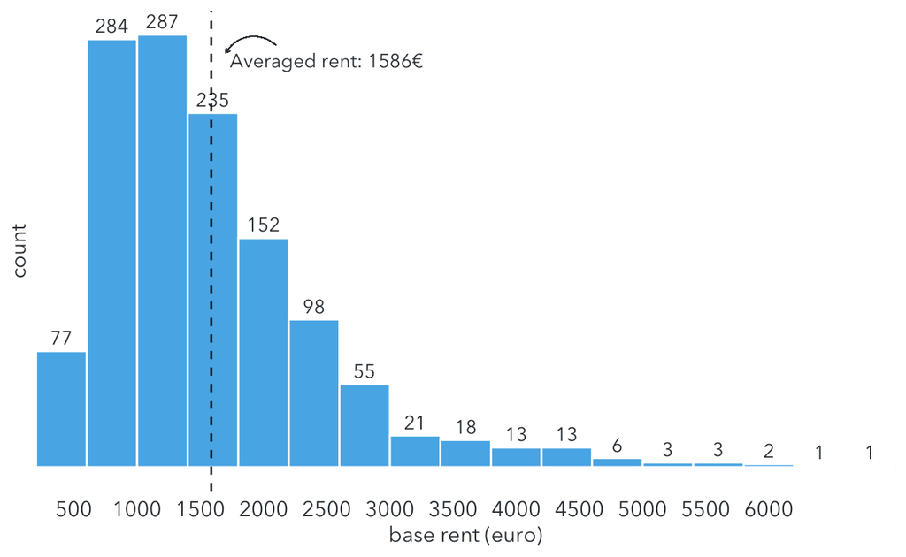

```r
ggplot(berlin_adjusted, aes(x = baserent)) +
  geom_histogram(fill = "#56B4E9", binwidth = 400, colour = "white") +
  stat_bin(binwidth = 400, aes(y = ..count.., label=..count..), geom="text", family = font, color = text_color, size = 3.5, vjust = -0.5) +
  geom_vline(xintercept = mean(berlin_adjusted$baserent), size = 0.5, linetype = 2) +
   geom_curve(aes(x = 2100, xend = 1700, y = 280, yend = 275),
             color = text_color,
             size = 0.2,
             arrow = arrow(length = unit(0.01, "npc"))) +
  ggplot2::annotate("text", x = 2500, y = 270,
           label = "Averaged rent: 1586€",
           family = font,
           color = text_color,
           size = 3.5) +
  scale_y_discrete(expand = c(0,16)) +
  scale_x_continuous(expand = c(0,0), name = "base rent (euro)", breaks = seq(0,6000,500))+
  theme(
    panel.background = element_blank(),
    axis.ticks = element_blank(),
    axis.text = element_text(family = font, color = text_color, size = 11),
    axis.title = element_text(family = font, color = text_color, size = 11)
  )
```

But that’s not the final expense. How much do they still have to pay for extra costs, such as heating, electricity, or interset? Let’s take a look at the distribution of `service`.

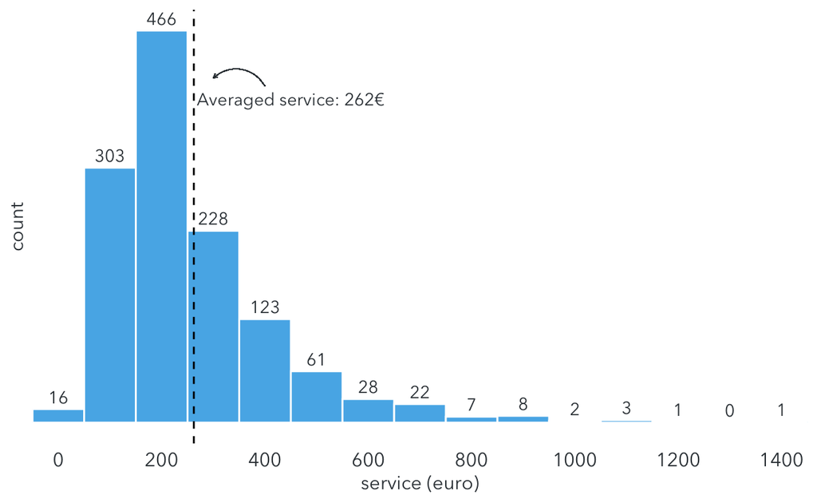

```r
ggplot(berlin_adjusted, aes(x = service)) +
  geom_histogram(fill = "#56B4E9", binwidth = 100, colour = "white") +
  stat_bin(binwidth = 100, aes(y = ..count.., label=..count..), geom="text", family = font, color = text_color, size = 3.5, vjust = -0.5) +
  geom_vline(xintercept = mean(berlin_adjusted$service), size = 0.5, linetype = 2) +
   geom_curve(aes(x = 400, xend = 300, y = 400, yend = 410),
             color = text_color,
             size = 0.2,
             arrow = arrow(length = unit(0.01, "npc"))) +
  ggplot2::annotate("text", x = 450, y = 385,
           label = "Averaged service: 262€",
           family = font,
           color = text_color,
           size = 3.5) +
  scale_y_discrete(expand = c(0,25)) +
  scale_x_continuous(expand = c(0,0), name = "service (euro)", breaks = seq(0,2000,200))+
  theme(
    panel.background = element_blank(),
    axis.ticks = element_blank(),
    axis.text = element_text(family = font, color = text_color, size = 11),
    axis.title = element_text(family = font, color = text_color, size = 11)
  )
```

The service price mainly ranges between 100 and 400€/month with the average of around 260€/month.

And how about the living space?

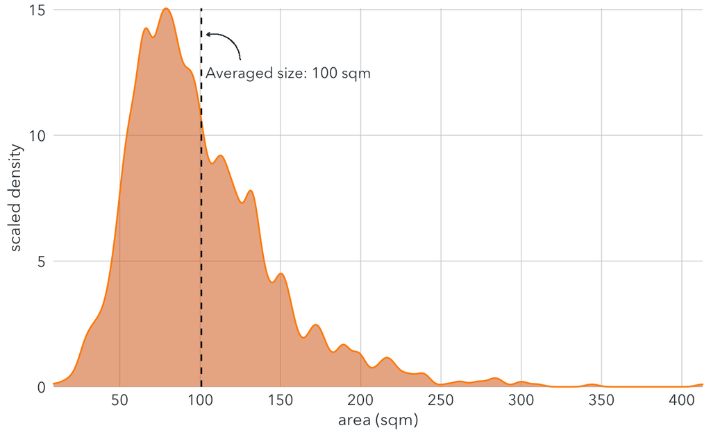

```r
ggplot(berlin_adjusted, aes(x = area, y = ..count..)) +
  geom_density_line(fill = "#D55E00", color = "darkorange", alpha = 0.5, bw = 4, kernel = "gaussian") +
  scale_y_continuous(expand = c(0,0), name = "scaled density") +
  scale_x_continuous(expand = c(0,0), name = "area (sqm)", breaks = seq(0, 400, 50)) +
  geom_vline(xintercept = mean(berlin_adjusted$area), size = 0.5, linetype = 2) +
   geom_curve(aes(x = 125, xend = 104, y = 13, yend = 14),
             color = text_color,
             size = 0.2,
             arrow = arrow(length = unit(0.01, "npc"))) +
  ggplot2::annotate("text", x = 155, y = 12.5,
           label = "Averaged size: 100 sqm",
           family = font,
           color = text_color,
           size = 3.5) +
  coord_cartesian(clip = "off") +
  theme(
    panel.background = element_blank(),
    panel.grid.major.y = element_line(color = "#cbcbcb", size = 0.2),
    panel.grid.major.x = element_line(color = "#cbcbcb", size = 0.2),
    axis.ticks = element_blank(),
    axis.text = element_text(family = font, color = text_color, size = 10),
    axis.title = element_text(family = font, color = text_color, size = 11))
```

The density plot shows that the area of most rental rents range between 50 and 150 sqm.

For interior decoration, there are three options: normal, sophisticated, and luxuty. Let’s see which option is more prevalent in Berlin rental properties.

```r
berlin_interior <- berlin_adjusted %>%
  group_by(interior) %>%
  summarize(
    count = n()/10)

waffle::waffle(
  setNames(berlin_interior$count, berlin_interior$interior),
  rows = 5,
  xlab = "1 square = 10 units"
)
```

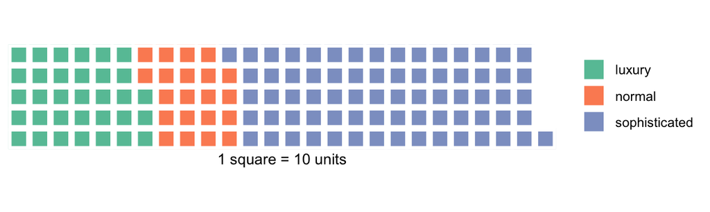

The number of rental properties labelled with sophisticated dominates, even larger than the total of normal and luxury interior.

# Modelling

Before starting with modelling, we need to transform some categorical into dummy variables for regression.

```r
berlin_final <- berlin_adjusted %>%
  mutate(
    balcony = as.numeric(balcony),
    kitchen = as.numeric(kitchen),
    cellar = as.numeric(cellar),
    garden = as.numeric(garden),
    new = as.numeric(new),
    lift = as.numeric(lift),
    interior = case_when(
      interior == "normal" ~ 0,
      interior == "sophisticated" ~ 1,
      interior == "luxury" ~ 1
    )
  )
```

Next, split the dataset into two parts: one for training and one for prediction.

```r
set.seed(1)
train <- sample(nrow(berlin_final), 700)
berlin_train <- berlin_final[train,]
berlin_test <- berlin_final[-train,]
```

Let’s start with the correlations between each pair of features.

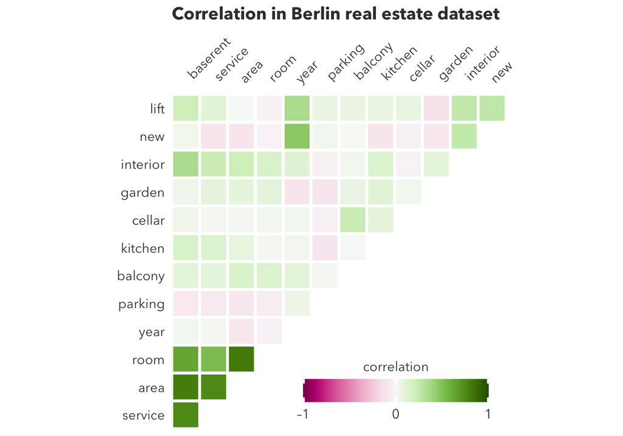

## Model 1: Simple linear regression

First, let’s take a look at the scatterplot between `baserent` and `area`.

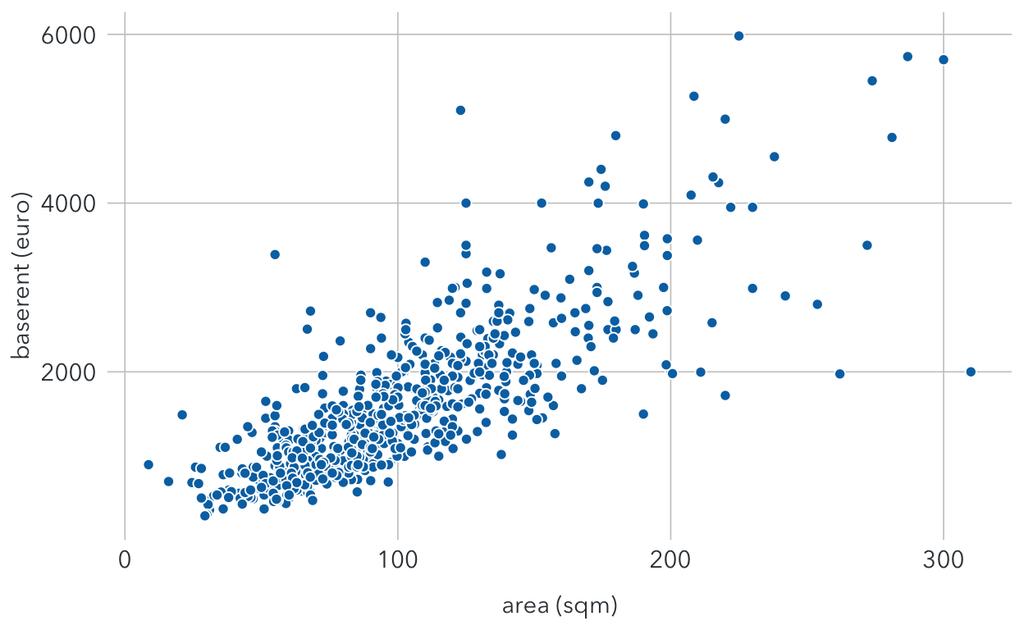

```r
ggplot(filter(berlin_train), aes(x = area, y = baserent)) +
  geom_point(shape = 21, fill = "#0072B2", color = "white", size = 2) +
  scale_x_continuous(name = "area (sqm)") +
  scale_y_continuous(name = "baserent (euro)") +
  theme(
    axis.ticks = element_blank(),
    axis.text = element_text(family = font, size = 11, color = text_color),
    axis.title = element_text(family = font, size = 11, color = text_color),
    panel.background = element_rect(fill = "white"),
    panel.grid.major = element_line(color = "#cbcbcb", size = 0.3),
    axis.title.x = element_text(margin = margin (t = 10)),
    legend.position = "none")
```

It shows that base rent and area seem to have a linear relationship. This means properties with more living space tend to have higher base rents. The linear regression for this relationship can be shown as:

$baserent = a + b*area + ε$, with ε is the error term, which includes other features that affect the base rent.

We can use the `lm()` function to find a and b.

```r
lm1 <- lm(baserent ~ area, data = berlin_train)
summary(lm1)
```

```
Call:
lm(formula = baserent ~ area, data = berlin_train)

Residuals:
    Min      1Q  Median      3Q     Max
-2892.6  -313.7   -85.6   239.6  3163.8

Coefficients:
            Estimate Std. Error t value Pr(>|t|)
(Intercept)  -8.3640    49.4648  -0.169    0.866
area         15.8095     0.4452  35.514   <2e-16 ***
---
Signif. codes:  0 '***' 0.001 '**' 0.01 '*' 0.05 '.' 0.1 ' ' 1

Residual standard error: 539.7 on 698 degrees of freedom
Multiple R-squared:  0.6437,    Adjusted R-squared:  0.6432
F-statistic:  1261 on 1 and 698 DF,  p-value: < 2.2e-16
```

$baserent ≈ -8.3640 + 15.8*area$

This means an increase of 1 sqm in the area may increase the base rent up to 15.8€. However, the accuracy of the model is quite low simply because the base rent can be determined by many other factors.

The residual standard error (RSE) is the estimate of the standard deviation of ε. In this case, it means observed base rents deviate from the true value by around 539.7, on average. With the mean value of `baserent` around 1592€, the percentage error is 539.7/1592 ≈ 34%.

The R-squared is 0.6437, meaning that the model can explain around 64% of the variance.

The graph below show the regression line with the standard error band.

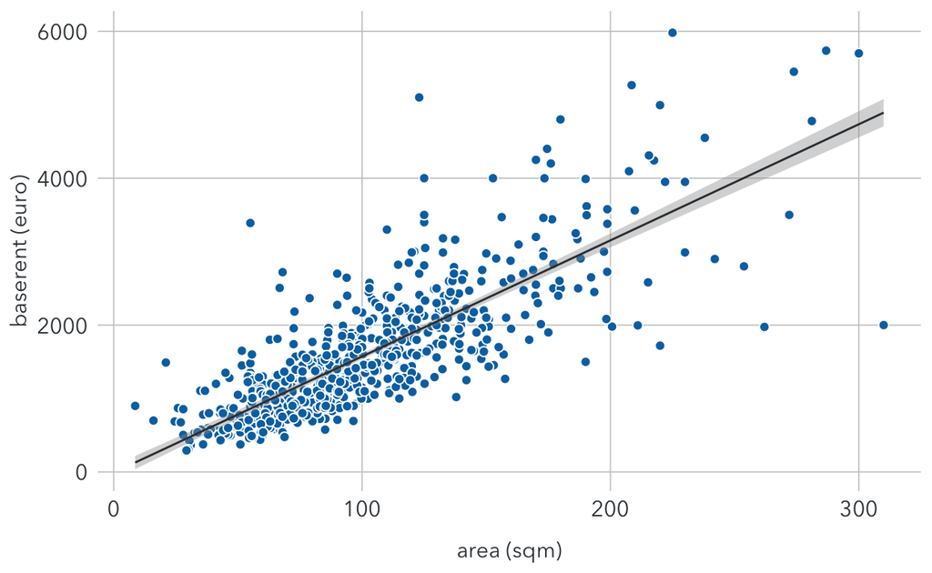

```r
ggplot(filter(berlin_train), aes(x = area, y = baserent)) +
  geom_point(shape = 21, fill = "#0072B2", color = "white", size = 2) +
  stat_smooth(method = "lm", color = text_color, size = 0.5) +
  scale_x_continuous(name = "area (sqm)") +
  scale_y_continuous(name = "baserent (euro)") +
  theme(
    axis.ticks = element_blank(),
    axis.text = element_text(family = font, size = 11, color = text_color),
    axis.title = element_text(family = font, size = 11, color = text_color),
    panel.background = element_rect(fill = "white"),
    panel.grid.major = element_line(color = "#cbcbcb", size = 0.3),
    axis.title.x = element_text(margin = margin (t = 10)),
    legend.position = "none")
```

## Model 2: Collinearity

Now let’s add a another feature `room` into the model.

```r
lm2 <- lm(baserent ~ area + room, data = berlin_train)
summary(lm2)
```

```
Call:
lm(formula = baserent ~ area + room, data = berlin_train)

Residuals:
     Min       1Q   Median       3Q      Max
-2965.15  -304.23   -83.49   242.55  3129.49

Coefficients:
            Estimate Std. Error t value Pr(>|t|)
(Intercept)  16.9313    58.9697   0.287    0.774
area         16.2667     0.7311  22.249   <2e-16 ***
room        -23.6147    29.9516  -0.788    0.431
---
Signif. codes:  0 '***' 0.001 '**' 0.01 '*' 0.05 '.' 0.1 ' ' 1

Residual standard error: 539.8 on 697 degrees of freedom
Multiple R-squared:  0.6441,    Adjusted R-squared:  0.643
F-statistic: 630.6 on 2 and 697 DF,  p-value: < 2.2e-16
```

The results indicate that `room` is not a statistically significant variable. This can be explained by a phenomenon called **collinearity**. It occurs when two variables are highly linearly related. In this case, we may think that properties with more room tend to have larger living areas.

## Model 3: Multiple linear regression

Now we regress the baserent on all features of the dataset.

```r
lm3 <- lm(baserent ~ ., data = berlin_train)
summary(lm3)
```

```
Call:
lm(formula = baserent ~ ., data = berlin_train)

Residuals:
    Min      1Q  Median      3Q     Max
-2291.9  -256.4   -48.6   181.9  2516.9

Coefficients:
             Estimate Std. Error t value Pr(>|t|)
(Intercept)    3.5579  1033.9914   0.003  0.99726
service        1.4856     0.1707   8.702  < 2e-16 ***
area          10.6220     0.8768  12.115  < 2e-16 ***
room          33.3269    27.1021   1.230  0.21924
year          -0.2360     0.5274  -0.447  0.65470
parking       -2.9201     3.4022  -0.858  0.39102
balcony      -74.1553    61.6560  -1.203  0.22950
kitchen      116.6264    43.0636   2.708  0.00693 **
cellar        58.4286    43.8037   1.334  0.18269
garden       -32.4150    39.9224  -0.812  0.41710
interior     308.2498    53.7373   5.736 1.45e-08 ***
new          104.4353    46.7379   2.234  0.02577 *
lift         219.6438    44.1091   4.980 8.07e-07 ***
---
Signif. codes:  0 '***' 0.001 '**' 0.01 '*' 0.05 '.' 0.1 ' ' 1

Residual standard error: 470.8 on 687 degrees of freedom
Multiple R-squared:  0.7331,    Adjusted R-squared:  0.7285
F-statistic: 157.3 on 12 and 687 DF,  p-value: < 2.2e-16
```

With more features included, RSS is significantly reduced and R-squared is also much higher. Statically significant variables include `service`, `area`, `kitchen`, `interior`, `new`, and `lift`.

# Prediction

Once we have done with modelling, it’s time to use the model for predicting the base rent in the test dataset. From a list of features as inputs, we can calculated predicted prices.

The following dataframe shows the actual and predicted prices of the test dataset, using 3 models above:

```r
pred.lm1 = predict(lm1, newdata = berlin_test)
pred.lm2 = predict(lm2, newdata = berlin_test)
pred.lm3 = predict(lm3, newdata = berlin_test)
prediction <- data.frame(berlin_test$baserent, pred.lm1, pred.lm2, pred.lm3) %>%
  rename(
    actual_price = berlin_test.baserent,
    predicted_model1 = pred.lm1,
    predicted_model2 = pred.lm2,
    predicted_model3 = pred.lm3
  )
rmarkdown::paged_table(prediction)
```

|  | actual_price | predicted_model1 | predicted_model2 | predicted_model3 |
| --- | --- | --- | --- | --- |
| 1 | 1150.00 | 725.1979 | 724.4775 | 1039.81854 |
| 2 | 1048.00 | 1306.0398 | 1298.5019 | 1262.31810 |
| 4 | 749.00 | 1094.3503 | 1104.3053 | 853.28302 |
| 7 | 1763.63 | 2526.3770 | 2459.6710 | 2624.98154 |
| 9 | 745.00 | 1066.6837 | 1064.0312 | 589.09720 |
| 10 | 2215.00 | 1872.9694 | 1858.2116 | 2375.31043 |
| 12 | 867.24 | 1134.1903 | 1145.2974 | 1135.88507 |
| 14 | 965.10 | 1761.6703 | 1767.3086 | 1153.92279 |
| 16 | 1704.68 | 1531.6418 | 1530.6279 | 1489.88211 |
| 18 | 2220.43 | 1699.8551 | 1680.0911 | 1801.08736 |

[output cut: 559 more lines]

To measure the accuracy of this regression model, we may calculate the root-mean-square error (RMSE). This metric simply calculates the average error of all predictions.

```r
RMSE1 = sqrt(mean((prediction$actual_price - prediction$predicted_model1)^2))
RMSE2 = sqrt(mean((prediction$actual_price - prediction$predicted_model2)^2))
RMSE3 = sqrt(mean((prediction$actual_price - prediction$predicted_model3)^2))
data.frame(RMSE1, RMSE2, RMSE3)
```

```
     RMSE1    RMSE2    RMSE3
1 546.8717 544.9041 451.3863
```

Model 3 has the smallest RMSE. So if we have to choose one, this should be a suitable option. This does not necessarily mean it is the best model for predicting future observations.

To increase the accuracy of prediction, we need to:  
- Increase the sample size by collecting more data on rental properties in Berlin  
- Include more relevant features linked to the base rent prices, such as the neighborhood, number of supermarkets or schools around, distance to the nearest bus or train station, etc.